# BSAN2204 A3 - Ton That Minh Anh - 2412580007

Tôn Thất Minh Anh (Student ID: 2412580007)

2026-10-15

# 1 . Introduction

This report provides a concise data summary and predictive analysis to support the client’s request for insights into airline booking intentions. The dataset contains responses from 300 participants and includes a range of attitudinal measures recorded on 1–5 Likert scales, such as Perceived_Credibility, Perceived_Value, Perceived_Risk, and Perceived_Quality. These variables represent aggregated agreement with statements relating to the airline’s brand, service quality, trustworthiness, and perceived benefits. The dataset also includes demographic variables such as Age, Sex, Education, and Income.

The outcome of interest, Booking_Intention, captures respondents’ stated likelihood of choosing to fly with the airline. Understanding the factors that influence this intention is critical for evaluating whether the client’s proposed marketing campaign—centred on credibility and brand messaging—is supported by the data.

This report follows a structured approach: first presenting descriptive statistics to summarise customer attitudes and demographic characteristics, followed by visualisations to highlight notable patterns in the data. A series of regression models is then estimated to identify the strongest predictors of Booking_Intention. Finally, the report provides clear and actionable recommendations that translate analytical findings into practical guidance for the client’s upcoming campaign.

# 2 . Exploratory Data Analysis

Desciptive statistics for continuous variables in the airline booking dataset

|  | n | mean | sd | skew | kurtosis |
| --- | --- | --- | --- | --- | --- |
| Perceived_Credibility | 300 | 3.811 | 0.806 | -0.893 | 1.077 |
| Perceived_Risk | 300 | 2.116 | 1.011 | 1.068 | 1.010 |
| Income | 209 | 14337.321 | 10527.658 | 1.308 | 3.251 |

The above descriptive statistics table shows the central tendency and variability of key continuous variables in the airline booking dataset. The average Perceived_Credibility of respondents is 3.811 (on a 1–5 Likert scale), which suggests that customers generally hold moderately positive views of the airline’s trustworthiness and reputation. This implies that the airline benefits from a baseline level of consumer confidence, making credibility a potentially important factor to consider in the client’s upcoming marketing campaign.

The average Perceived_Risk in the dataset is 2.116 (Likert scale), indicating that respondents perceive relatively low levels of risk when evaluating the airline. This low-risk perception reduces psychological barriers to booking and suggests that customers do not commonly associate the brand with safety concerns, operational issues, or uncertainty. Such findings reflect positively on the airline’s existing market position and highlight that risk reduction messaging may not be as critical as reinforcing credibility.

Overall, the descriptive statistics reveal that the sample consists of respondents who generally view the airline favourably, perceive low risk, and vary widely in financial capacity. These initial insights provide an important foundation for assessing how attitudes and demographic factors shape Booking_Intention in the subsequent predictive analysis.

# 3 . Visualization

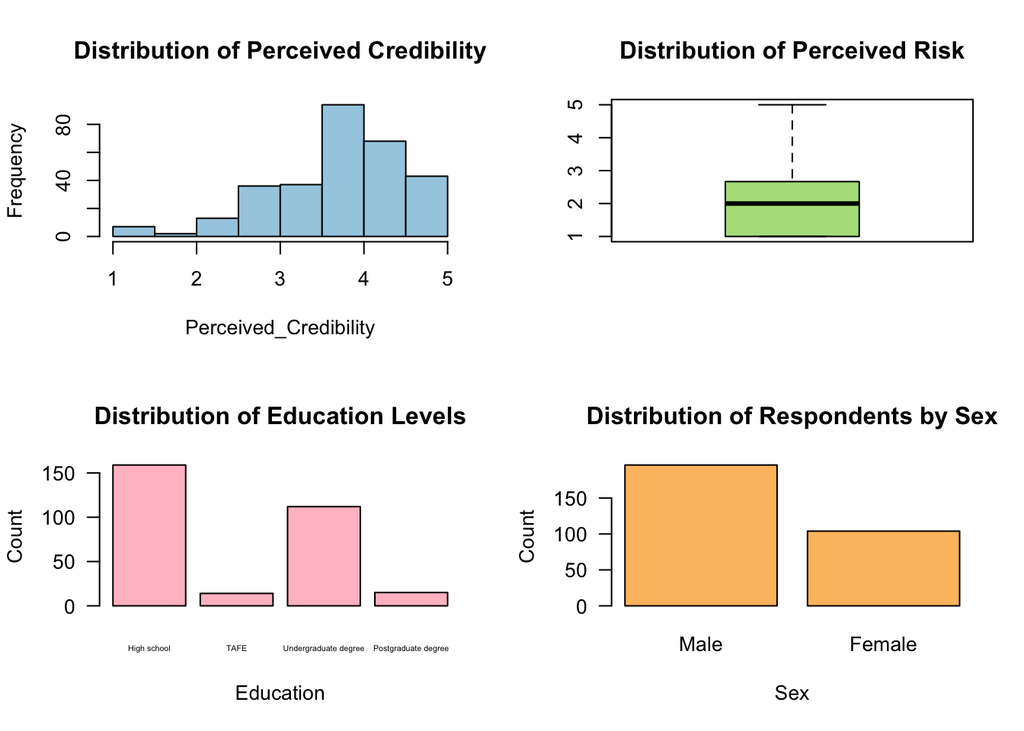

My main Variables of Interest are now plotted seperately:

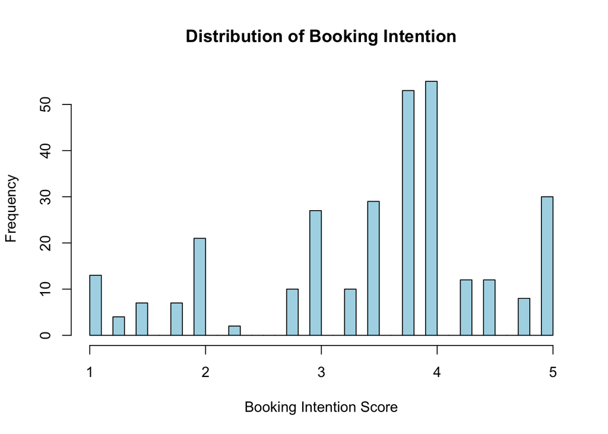

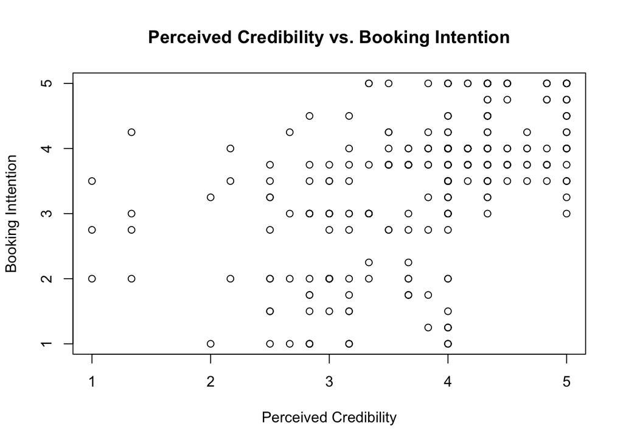

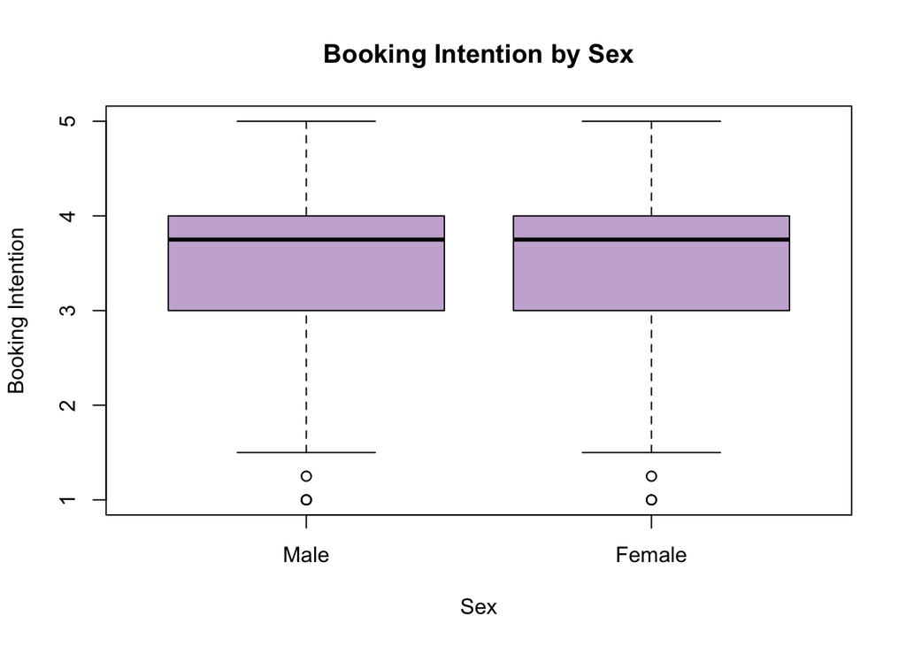

# 4 . Predictive Analysis

## 4.1 . Regression model specification

To identify the key factors influencing customers’ likelihood to book with the airline, several linear regression models were estimated using Booking_Intention as the dependent variable. The main predictors selected were Perceived_Credibility, Perceived_Risk, and Perceived_Value, as these attitude variables capture trust, perceived uncertainty, and perceived benefits, which are central to the client’s marketing objectives. Because credibility may not have a purely linear effect, a squared term (I(Perceived_Credibility²)) was included in some models to allow for possible non-linear relationships.

The five models progress from simple additive structures to more complex specifications with non-linear and interaction terms, allowing comparison of model fit and identification of the most streamlined and informative model.

## 4.2 . Regression Model

```r
m1 <- lm(Booking_Intention ~ Perceived_Credibility + Perceived_Risk + Perceived_Value)
m2 <- lm(Booking_Intention ~ Perceived_Credibility + Perceived_Risk + I(Perceived_Credibility^2))
m3 <- lm(Booking_Intention ~ Perceived_Credibility + Perceived_Risk + Perceived_Credibility:Perceived_Risk)
m4 <- lm(Booking_Intention ~ Perceived_Credibility + Perceived_Risk + Perceived_Value + Income)
m5 <- lm(Booking_Intention ~ Perceived_Credibility + Perceived_Risk + Perceived_Credibility:Perceived_Risk + I(Perceived_Credibility^2))
```

|  | Dependent variable |  | Dependent variable |  | Dependent variable |  | Dependent variable |  | Dependent variable |  |
| --- | --- | --- | --- | --- | --- | --- | --- | --- | --- | --- |
| Predictors | Estimates | p | Estimates | p | Estimates | p | Estimates | p | Estimates | p |
| (Intercept) | 1.00 | **0.015** | 2.90 | **<0.001** | -0.14 | 0.808 | 1.48 | **0.003** | 2.28 | **0.016** |
| Perceived Credibility | 0.70 | **<0.001** | -0.62 | 0.089 | 0.95 | **<0.001** | 0.52 | **<0.001** | -0.39 | 0.361 |
| Perceived Risk | 0.00 | 0.971 | 0.01 | 0.815 | 0.39 | 0.062 | -0.08 | 0.215 | 0.21 | 0.332 |
| Perceived Value | -0.05 | 0.378 |  |  |  |  | -0.08 | 0.242 |  |  |
| Perceived Credibility^2 |  |  | 0.19 | **<0.001** |  |  |  |  | 0.18 | **0.001** |
| Perceived Credibility × Perceived Risk |  |  |  |  | -0.11 | 0.060 |  |  | -0.05 | 0.347 |
| Income |  |  |  |  |  |  | 0.00 | **<0.001** |  |  |
| Observations | 300 |  | 300 |  | 300 |  | 209 |  | 300 |  |
| R<sup>2</sup> / R<sup>2</sup> adjusted | 0.284 / 0.277 |  | 0.314 / 0.307 |  | 0.291 / 0.284 |  | 0.344 / 0.332 |  | 0.316 / 0.307 |  |

# 5 . Advice and Recommendation

Additionally, Income is significant in Model 4 (p < 0.001), indicating that higher-income customers show stronger booking intentions. While this variable cannot be directly influenced by marketing activity, it highlights an opportunity to target higher-income customer segments through tailored promotions or premium service offerings.

In contrast, variables such as Perceived_Risk and Perceived_Value are not statistically significant (p > 0.05), meaning they do not reliably predict booking intention once credibility and demographics are taken into account. Therefore, the client should not prioritise these attributes in their immediate campaign strategy.

From a managerial perspective, the airline should design a marketing campaign that reinforces brand credibility through trust-building messaging—for example, emphasising safety records, reliability, transparency, and strong service performance. Testimonials, third-party certifications, and consistent communication around operational excellence can also strengthen perceived credibility. By focusing on this key driver and by targeting high-income customer segments, the airline can more effectively steer its campaign to increase booking intentions.